| title: “Coorong habitat quality waterbird abundance models” |
| --- |
| author: “Micha Jackson, Steven Delean, Thomas Prowse, Rowan Mott” |
| date: ‘2022-07-19’ |
| output: |
| html_document: default |

Load packages.

```r
library(bbmle)
library(broom.mixed)
library(car)
library(colorBlindness)
library(DHARMa)
library(emmeans)
library(glmmTMB)
library(lubridate)
library(MuMIn)
library(performance)
library(scales)
library(sjPlot)
library(tidyverse)
```

Import and organise shorebird count data:

Remove records where mudflat area = NA.

Add variables for survey month, time of day and potential habitat i.e. mudflat (converted to hectares) + shallow water area.

Calculate mean salinity and potential habitat (mudflat + shallow water area) over the whole time series at each site.

Calculate site-centred values for salinty and potential habitat (mudflat + shallow water area).

Simplify wind direction values to a binary north/not north value.

Take the maximum from the two counts completed at each unique site/date/time-of-day combination, and then calculate total abundance.

Add variables for interaction terms between site, time-of-day and month.

```r
shorecounts_unprocessed <- read_csv("./01_data/CoorongShorebirdCounts.csv")

shorecounts <- shorecounts_unprocessed %>%
  filter(!is.na(MudflatAreaM)) %>%
  mutate(Date = as.Date(Date, "%d/%m/%Y")) %>%
  mutate(month = factor(format(Date, "%m"),
         levels = c('04', '06', '08', '10', '12', '02', '03'))) %>%
  mutate(tod = if_else(am(Starttime), "am", "pm"),
         mudshal = MudflatAreaM*.0001+ShallowAreaha) %>%
  group_by(Site) %>%
  mutate(avgsal = mean(Salinity),
         avgmudshal = mean(mudshal)) %>%
  mutate(Salinity.c = as.vector(scale(Salinity, scale = TRUE)),
         Mudshal.c = as.vector(scale(mudshal, scale = TRUE))) %>%
  ungroup() %>%
  mutate(Winddirection = dplyr::recode(Winddirection, E="Oth", ENE="Oth", ESE="Oth",
                         NE="N", NNE="N", NNW="N", NW="N", S="Oth", SE="Oth", SSE="Oth",
                         SSW="Oth", SW="Oth", W="Oth", WNW="Oth", WSW="Oth"))

shorecounts <- shorecounts %>%
  group_by(Date, Site, Temperature, Winddirection, Windspeed,
           Salinity, MudflatAreaM, ShallowAreaha,
           mudshal, avgsal, avgmudshal, Salinity.c, Mudshal.c,
           tod, month) %>%
  summarise(across(BandedStilt:SmallShorebird, ~ max(., na.rm = FALSE)))

shorecounts <- shorecounts %>%
  rowwise() %>%
  mutate(shoreabun = sum(c_across(BandedStilt:SmallShorebird), na.rm=T))

shorecounts <- shorecounts %>%
  mutate(siteTOD = interaction(Site, tod, drop = TRUE),
         siteMonth = interaction(Site, month, drop = TRUE),
         todMonth = interaction(tod, month, drop = TRUE),
         siteTODMonth = interaction(Site, tod, month, drop = TRUE))
```

Summarise shorebird data. Summaries:

2 - Calculate (take the maximum from two counts at the same site/month and sum across all sites in each months) and plot maximum monthly abundance of all shorebirds and each shorebird species.

3 - Calculate (take the maximum from two counts at the same site/month and sum across all sites in all months). Plot total individuals counted across all months for each site, showing each species separately and displaying as a proportion of the total number of individuals counted at the site over the study period.

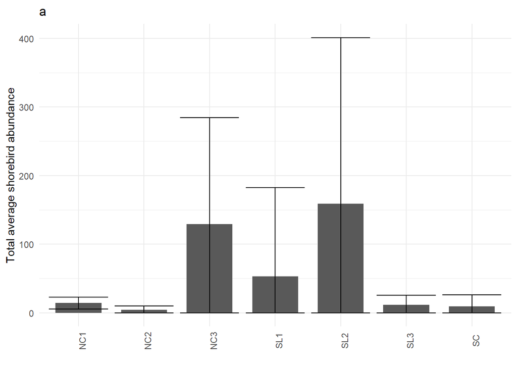

```r
countsavg <- shorecounts %>%
  ungroup() %>%
  select(Site, month, BandedStilt, RedcappedPlover, RedcappedPlover, RedneckedAvocet,  shoreabun) %>%
  gather(Species, Counts, BandedStilt:shoreabun) %>%
  group_by(Site, Species) %>%
  summarise(meancount=mean(Counts),
            sdcount=sd(Counts))

countsavg <- countsavg  %>%
  mutate(Species = dplyr::recode(Species,
                                 shoreabun="Total abundance",
                                 BandedStilt="Banded Stilt",
                                 RedcappedPlover="Red-capped Plover",
                                 RedneckedAvocet="Red-necked Avocet",
                                 RedneckedStint="Red-necked Stint"))

countsavgtot <- countsavg %>%
  filter(Species == "Total abundance")

countsavgsel <- countsavg %>%
  filter(Species != "Total abundance")

level_order <- c('NC1', 'NC2', 'NC3', 'SL1', 'SL2', 'SL3', 'SC')

plotsiteavg1 <- ggplot(countsavgtot, aes(x=factor(Site, level = level_order), y=meancount))+
  geom_bar(stat="identity", width=0.7) +
  geom_errorbar(aes(x=factor(Site, level = level_order),
                ymin=ifelse(meancount-sdcount< 0, 0, meancount-sdcount),
                ymax=meancount+sdcount)) +
  theme_minimal() +
  theme(axis.text.x = element_text(angle = 90)) +
  labs(x = "", y = "Total average shorebird abundance") +
  ggtitle("a")
plotsiteavg1
```

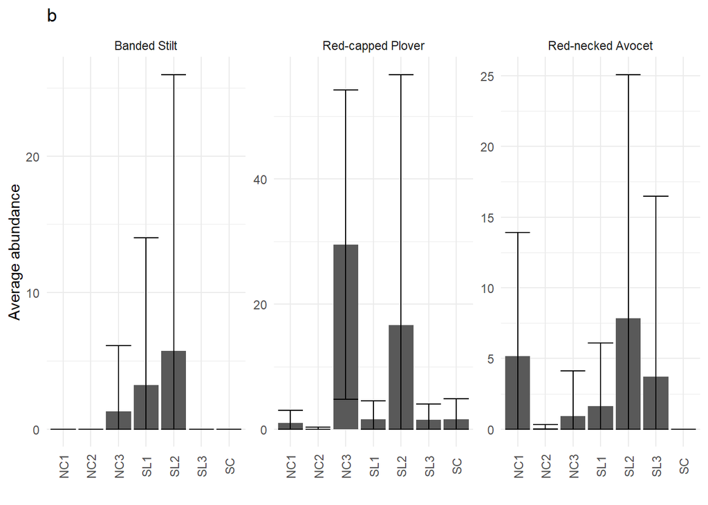

```r
ggsave("./03_plots/plotsiteavg1.png", plot = plotsiteavg1, width = 6, height = 3, dpi = 300)

plotsiteavg2 <- ggplot(countsavgsel, aes(x=factor(Site, level = level_order), y=meancount)) +
  geom_bar(stat="identity", width=0.9) +
  geom_errorbar(aes(x=factor(Site, level = level_order), ymin=ifelse(meancount-sdcount< 0, 0,
                meancount-sdcount), ymax=meancount+sdcount)) +
  theme_minimal() +
  theme(axis.text.x = element_text(vjust=0.5, angle = 90)) +
  facet_wrap(~Species, ncol = 4, scales = "free") +
  labs(x = "", y = "Average abundance") +
  ggtitle("b") +
  theme(legend.position="none")
plotsiteavg2
```

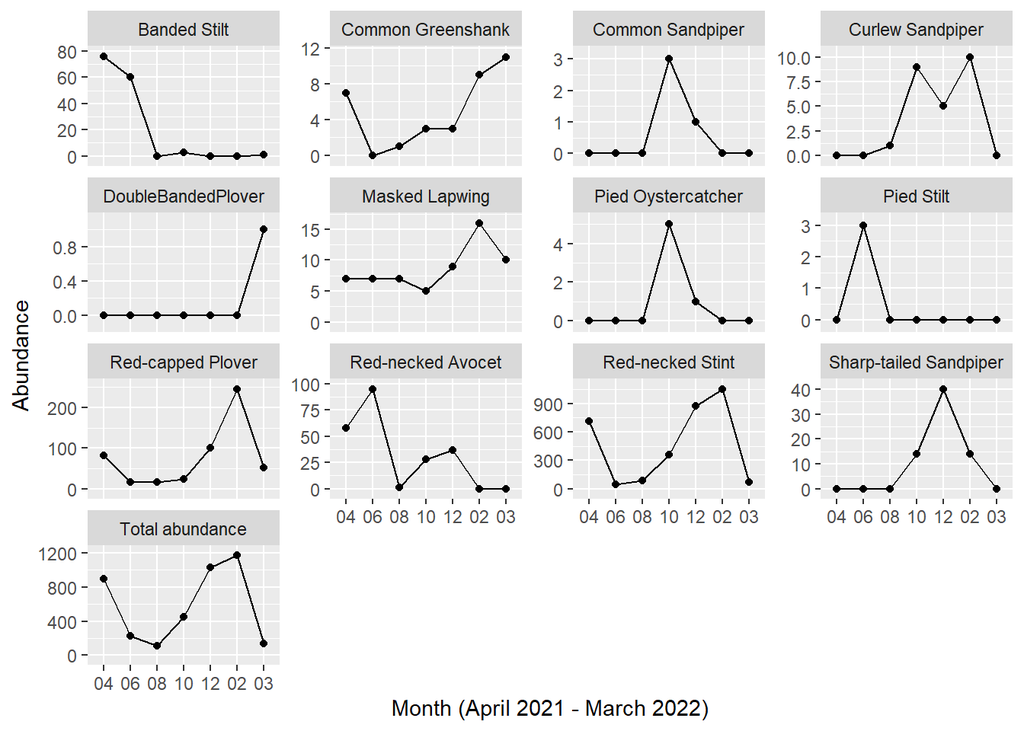

```r
ggsave("./03_plots/plotsiteavg2.png", plot = plotsiteavg2, width = 6, height = 2, dpi = 300)

monthcountmax <- shorecounts %>%
  group_by(Site, month) %>%
  summarise(across(BandedStilt:shoreabun, ~ max(., na.rm = TRUE)))

monthcountmax <- monthcountmax %>%
  group_by(month) %>%
  summarise(across(BandedStilt:shoreabun, ~ sum(., na.rm = TRUE)))

monthcountmax <- monthcountmax %>%
  gather(Species, Abundance, BandedStilt:shoreabun) %>%
  filter(Species!="SmallShorebird")

monthcountmax <- monthcountmax %>%
  mutate(Species = dplyr::recode(Species,
                                 shoreabun="Total abundance",
                                 BandedStilt="Banded Stilt",
                                 CommonGreenshank="Common Greenshank",
                                 CommonSandpiper="Common Sandpiper",
                                 CurlewSandpiper="Curlew Sandpiper",
                                 MaskedLapwing="Masked Lapwing",
                                 PiedOystercatcher="Pied Oystercatcher",
                                 PiedStilt = "Pied Stilt",
                                 RedcappedPlover="Red-capped Plover",
                                 RedneckedAvocet="Red-necked Avocet",
                                 RedneckedStint="Red-necked Stint",
                                 SharptailedSandpiper="Sharp-tailed Sandpiper"))

plotmonthabun <- ggplot(monthcountmax, aes(x=month, y=Abundance, group=1)) +
  geom_point () +
  geom_line () +
  scale_y_continuous(expand = c(0.1, 0.1), limits = c(0, NA)) +
  labs(x = "Month (April 2021 - March 2022)", y = "Abundance") +
  facet_wrap(~Species, scales = "free_y")
plotmonthabun
```

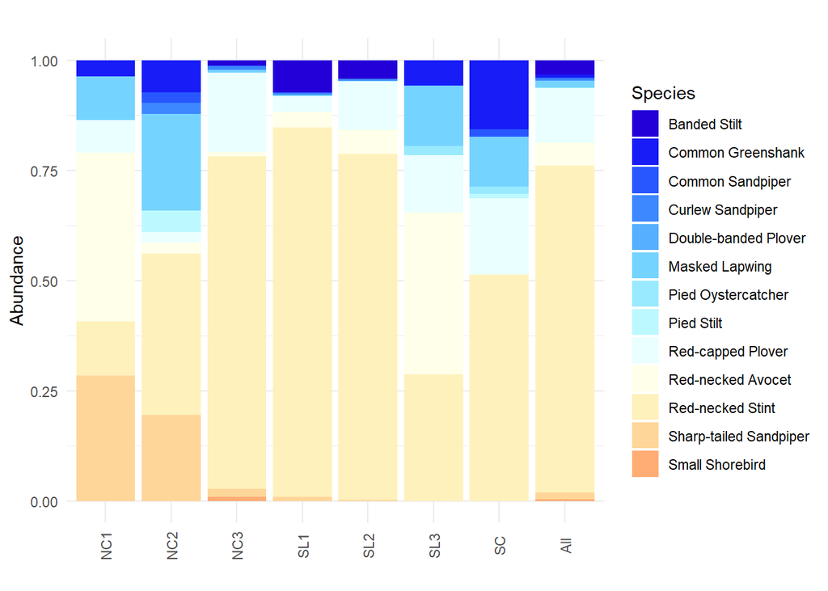

```r
ggsave("./03_plots/plotmonthabun.png", plot = plotmonthabun, width = 7, height = 4, dpi = 300)

allmonthscountmax <- shorecounts %>%
  group_by(Site, month) %>%
  summarise(across(BandedStilt:shoreabun, ~ max(., na.rm = TRUE)))

allmonthscountmax <- allmonthscountmax %>%
  summarise(across(BandedStilt:shoreabun, ~ sum(., na.rm = TRUE)))

allmonthscountmax <- allmonthscountmax %>%
  gather(Species, Abundance, BandedStilt:shoreabun)%>%
  filter(Species!="shoreabun")%>%
  spread(Site, Abundance)%>%
  rowwise() %>%
  mutate(All = sum(c_across(NC1:SL3), na.rm=T))%>%
  gather(Site, Abundance, NC1:All)

level_order1 <- c('NC1', 'NC2', 'NC3', 'SL1', 'SL2', 'SL3', 'SC', 'All')

allmonthscountmax <- allmonthscountmax %>%
  mutate(Species = dplyr::recode(Species,
                                 BandedStilt="Banded Stilt",
                                 CommonGreenshank="Common Greenshank",
                                 CommonSandpiper="Common Sandpiper",
                                 CurlewSandpiper="Curlew Sandpiper",
                                 DoubleBandedPlover="Double-banded Plover",
                                 MaskedLapwing="Masked Lapwing",
                                 PiedOystercatcher="Pied Oystercatcher",
                                 PiedStilt = "Pied Stilt",
                                 RedcappedPlover="Red-capped Plover",
                                 RedneckedAvocet="Red-necked Avocet",
                                 RedneckedStint="Red-necked Stint",
                                 SharptailedSandpiper="Sharp-tailed Sandpiper",
                                 SmallShorebird="Small Shorebird"))

plotallmonthsmax <- ggplot(allmonthscountmax, aes(fill = Species, x=factor(Site, level = level_order1), y=Abundance)) +
  geom_bar(position="fill", stat="identity", width=0.9) +
  theme_minimal() +
  theme(axis.text.x = element_text(vjust=0.5, angle = 90)) +
  labs(x = "", y = "Abundance") +
  ggtitle("")
plotallmonthsmax <- plotallmonthsmax +  scale_fill_manual(values=Blue2DarkRed18Steps)
plotallmonthsmax
```

```r
ggsave("./03_plots/plotallmonthsmax.png", plot = plotallmonthsmax, width = 6, height = 5, dpi = 300)
```

Plot site characteristics

1 - Calculate mean salinity at each site and plot with vertical lines showing the range of values recorded.

2 - Calculate mean potential habitat area (i.e. mudflat area + shallow water area) at each site and plot with vertical lines showing the range of values recorded.

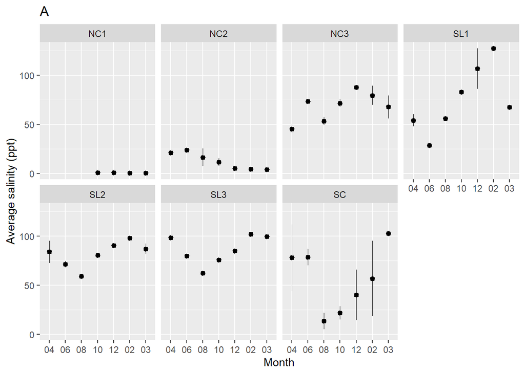

```r
monthlysitesal <-
  shorecounts %>%
  select(Date, Site, month, Salinity) %>%
  group_by(Site, month) %>%
  summarise(avgsal=mean(Salinity),
            maxsal=max(Salinity),
            minsal=min(Salinity))

monthlysitesal <- arrange(transform(monthlysitesal,
       Site=factor(Site,levels=level_order)),Site)

monthlysitesalplot <-
  ggplot(monthlysitesal, aes(month, avgsal)) +
  geom_point(size=0.5) +
  geom_pointrange(aes(ymin = minsal, ymax = maxsal), size=0.3)+
  labs(x = "Month", y = "Average salinity (ppt)") +
  ggtitle ("A") +
  facet_wrap(~Site, ncol = 4)
monthlysitesalplot
```

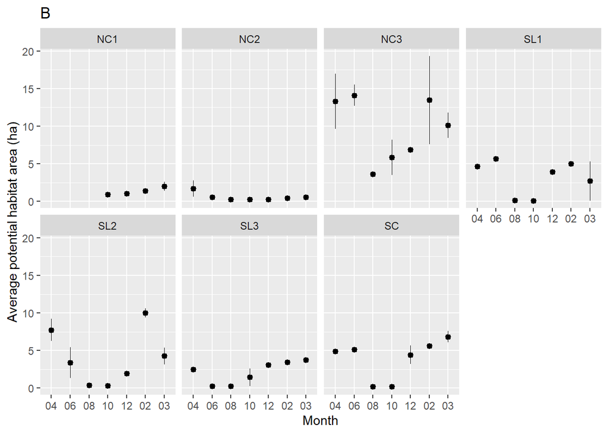

```r
ggsave("./03_plots/monthlysitesalplot.png", plot = monthlysitesalplot, width = 6, height = 3, dpi = 300)

monthlysitehab <-
  shorecounts %>%
  select(Date, Site, month, mudshal) %>%
  group_by(Site, month) %>%
  summarise(avghab=mean(mudshal),
            maxhab=max(mudshal),
            minhab=min(mudshal))

monthlysitehab <- arrange(transform(monthlysitehab,
       Site=factor(Site,levels=level_order)),Site)

monthlysitehabplot <-
  ggplot(monthlysitehab, aes(month, avghab)) +
  geom_point(size=0.5) +
  geom_pointrange(aes(ymin = minhab, ymax = maxhab), size=0.3)+
  labs(x = "Month", y = "Average potential habitat area (ha)") +
  ggtitle ("B") +
  facet_wrap(~Site, ncol = 4)
monthlysitehabplot
```

```r
ggsave("./03_plots/monthlysitehabplot.png", plot = monthlysitehabplot, width = 6, height = 3, dpi = 300)
```

Import and summarise benthic sampling data:

Add a variable for survey month (based on recorded survey date) and total benthic items.

Summaries:

1 - Sum across all sites in all months and create table with proportion of total for each benthic taxa.

2 - Take the mean, minimum and maximum total benthic items and each prey item (Simplisetia polychaetes, chironomid larvae and amphipods) across all samples at each site per month; standardise to m2 and create a figure for each.

```r
benthic_data <- read_csv("./01_data/CoorongBenthicSampling.csv")

benthictotal <- benthic_data %>%
  mutate(Total = select(., Oligochaeta:Other) %>%
         rowSums(na.rm = TRUE)) %>%
  mutate(Date = as.Date(Date, "%d/%m/%Y")) %>%
  mutate(month = factor(format(Date, "%m"),
         levels = c('04', '06', '08', '10', '12', '02', '03')))

benthictable <- benthictotal %>%
  summarise(across(Oligochaeta:Total, ~ sum(., na.rm = TRUE))) %>%
  gather(taxa, total_count) %>%
  mutate(percentage = total_count/15039*100)%>%
  mutate_at(3, round, 2)%>%
  arrange(desc(total_count))
benthictable
```

```
## # A tibble: 28 × 3
##    taxa                    total_count percentage
##    <chr>                         <dbl>      <dbl>
##  1 Total                         15039     100
##  2 Diptera_Chironomid             5133      34.1
##  3 Amphipod                       4090      27.2
##  4 Oligochaeta                    2135      14.2
##  5 Polychaete_Capitella           1095       7.28
##  6 Polychaete_Simplisetia          781       5.19
##  7 Batillariella_estuarina         527       3.5
##  8 Diptera_Stratiomyid             367       2.44
##  9 Diptera_Ceratopogonid           245       1.63
## 10 Diptera adult                   212       1.41
## # … with 18 more rows
## # ℹ Use `print(n = ...)` to see more rows
```

```r
tab_df(benthictable, file='./04_outputs/benthictable.doc')
```

| taxa | total_count | percentage |
| --- | --- | --- |
| Total | 15039 | 100.00 |
| Diptera_Chironomid | 5133 | 34.13 |
| Amphipod | 4090 | 27.20 |
| Oligochaeta | 2135 | 14.20 |
| Polychaete_Capitella | 1095 | 7.28 |
| Polychaete_Simplisetia | 781 | 5.19 |
| Batillariella_estuarina | 527 | 3.50 |
| Diptera_Stratiomyid | 367 | 2.44 |
| Diptera_Ceratopogonid | 245 | 1.63 |
| Diptera adult | 212 | 1.41 |
| Springtails (Collembola) | 84 | 0.56 |
| Ceratopogonid_pupae | 81 | 0.54 |
| Bivalve_Arthritica | 68 | 0.45 |
| Diptera_Dolichopodid | 55 | 0.37 |
| Gastropod_Hydrobia | 55 | 0.37 |
| Stratiomyid_pupae | 42 | 0.28 |
| Diptera_Ephydridae | 17 | 0.11 |
| Ostracod | 16 | 0.11 |
| Empididae | 10 | 0.07 |
| Gastropod_Salinator | 7 | 0.05 |
| Cafius sp | 4 | 0.03 |
| Hydrophilidae | 4 | 0.03 |
| Micronecta_sp | 3 | 0.02 |
| Pupae_Fly sp | 3 | 0.02 |
| Other | 3 | 0.02 |
| Polychaete_Australonereis | 1 | 0.01 |
| Polychaete_Boccardiella | 1 | 0.01 |
| Polychaete_Phyllodoce | 0 | 0.00 |

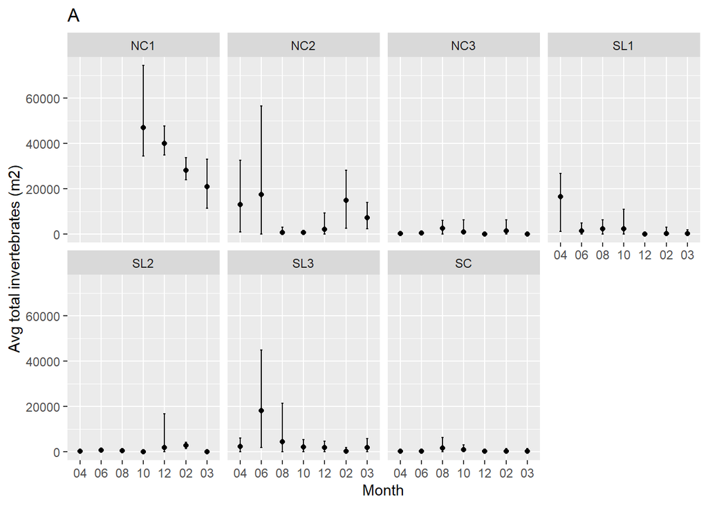

```r
benthicavg <- benthictotal %>%
  select(Site, month, Total, Polychaete_Simplisetia, Diptera_Chironomid, Amphipod) %>%
  group_by(Site, month) %>%
  summarise(avgtot = mean(Total),
         maxtotal = max(Total),
         mintotal = min(Total),
         avgsimp = mean(Polychaete_Simplisetia),
         maxsimp = max(Polychaete_Simplisetia),
         minsimp = min(Polychaete_Simplisetia),
         avgchi = mean(Diptera_Chironomid),
         maxchi = max(Diptera_Chironomid),
         minchi = min(Diptera_Chironomid),
         avgamp = mean(Amphipod),
         maxamp = max(Amphipod),
         minamp = min(Amphipod))

benthicavg1 <- benthicavg %>%
  mutate(avgtotm2 = avgtot*(1/0.0064),
         maxtotm2 = maxtotal*(1/0.0064),
         mintotm2 = mintotal*(1/0.0064),
         avgsimpm2 = avgsimp*(1/0.0064),
         maxsimpm2 = maxsimp*(1/0.0064),
         minsimpm2 = minsimp*(1/0.0064),
         avgchim2 = avgchi*(1/0.0064),
         maxchim2 = maxchi*(1/0.0064),
         minchim2 = minchi*(1/0.0064),
         avgampm2 = avgamp*(1/0.0064),
         maxampm2 = maxamp*(1/0.0064),
         minampm2 = minamp*(1/0.0064),
         )

level_order1 <- c('NC1', 'NC2', 'NC3', 'SL1', 'SL2', 'SL3', 'SC')

benthicavg1 <- arrange(transform(benthicavg1,
                Site=factor(Site,levels=level_order1)),Site)

benthicavgtotpersite <-
  ggplot(benthicavg1, aes(month, avgtotm2)) +
  geom_point() +
  geom_errorbar(aes(ymin=mintotm2, ymax=maxtotm2), width=.1)+
  labs(x = "Month", y = "Avg total invertebrates (m2)") +
  facet_wrap(~Site, ncol = 4) +
  ggtitle("A")
benthicavgtotpersite
```

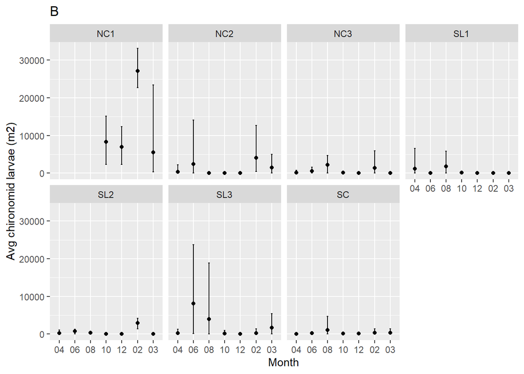

```r
ggsave("./03_plots/benthicavgtotpersite.png", plot = benthicavgtotpersite, width = 6, height = 3, dpi = 300)

benthicavgchironpersite <-
  ggplot(benthicavg1, aes(month, avgchim2)) +
  geom_point() +
  geom_errorbar(aes(ymin=minchim2, ymax=maxchim2), width=.1)+
  labs(x = "Month", y = "Avg chironomid larvae (m2)") +
  facet_wrap(~Site, ncol = 4) +
  ggtitle("B")
benthicavgchironpersite
```

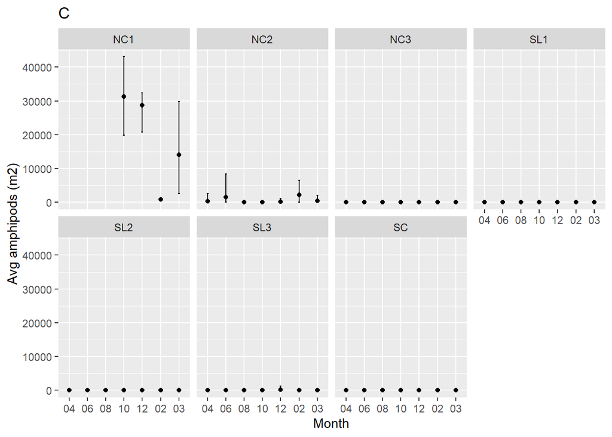

```r
ggsave("./03_plots/benthicavgchironpersite.png", plot = benthicavgchironpersite, width = 6, height = 3, dpi = 300)

benthicavgamppersite <-
  ggplot(benthicavg1, aes(month, avgampm2)) +
  geom_point() +
  geom_errorbar(aes(ymin=minampm2, ymax=maxampm2), width=.1)+
  labs(x = "Month", y = "Avg amphipods (m2)") +
  facet_wrap(~Site, ncol = 4)+
  ggtitle("C")
benthicavgamppersite
```

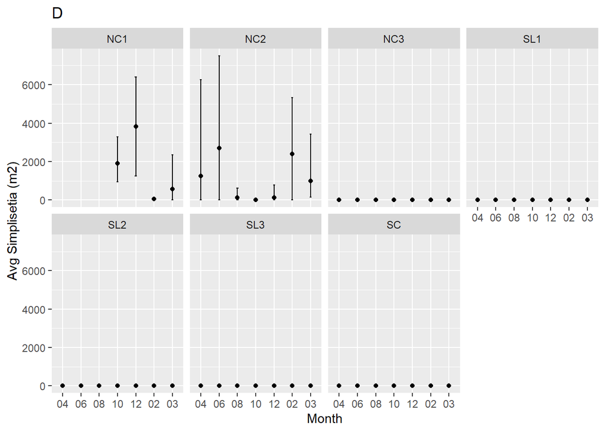

```r
ggsave("./03_plots/benthicavgamppersite.png", plot = benthicavgamppersite, width = 6, height = 3, dpi = 300)

benthicavgsimppersite <-
  ggplot(benthicavg1, aes(month, avgsimpm2)) +
  geom_point() +
  geom_errorbar(aes(ymin=minsimpm2, ymax=maxsimpm2), width=.1)+
  labs(x = "Month", y = "Avg Simplisetia (m2)") +
  facet_wrap(~Site, ncol = 4) +
  ggtitle("D")
benthicavgsimppersite
```

```r
ggsave("./03_plots/benthicavgsimppersite.png", plot = benthicavgsimppersite, width = 6, height = 3, dpi = 300)
```

Prepare benthic sampling data for abundance modelling:

Filter only to prey species. Add a variable for survey month (based on recorded survey date), total prey items (sum of Simplisetia polychaetes, chironomid larvae and amphipods) and an interaction term for site, time-of-day and month.

Explore data distribution.

Calculate the prey density = mean prey items per sample at each site on each sampling day, then take the log of density + 1.

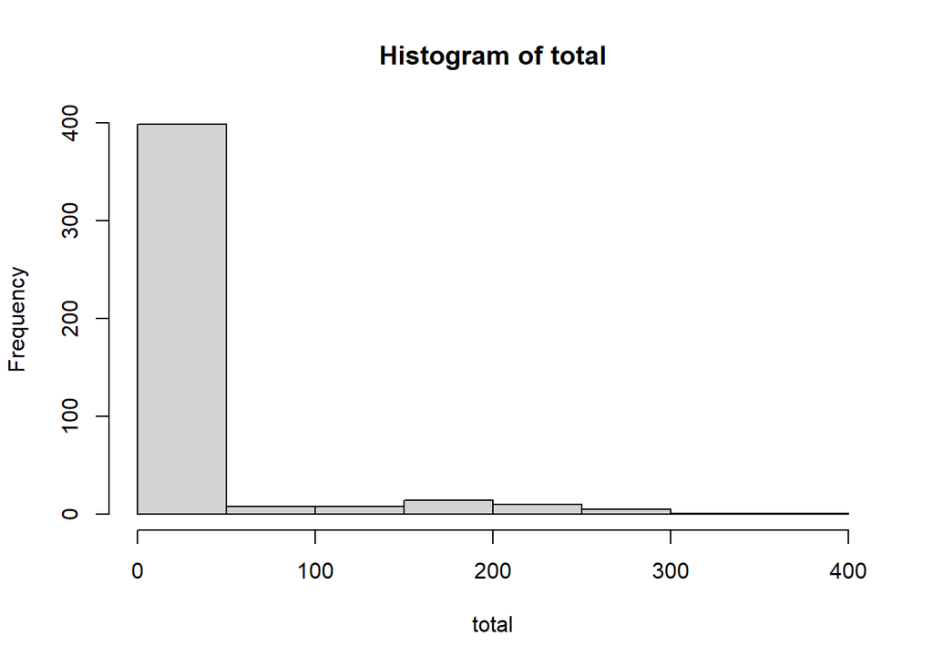

```r
prey_data <- benthic_data %>%
  select(Date, tod, Site, Sample_num, Polychaete_Simplisetia, Diptera_Chironomid, Amphipod)

preytotal <- prey_data %>%
  mutate(Date = as.Date(Date, "%d/%m/%Y")) %>%
  mutate(month = factor(format(Date, "%m"),
         levels = c('04', '06', '08', '10', '12', '02', '03'))) %>%
  mutate(total = select(., Polychaete_Simplisetia:Amphipod) %>%
         rowSums(na.rm = TRUE)) %>%
  mutate (siteTODMonth = interaction(Site, tod, month, drop = TRUE))

with(preytotal, hist(total))
```

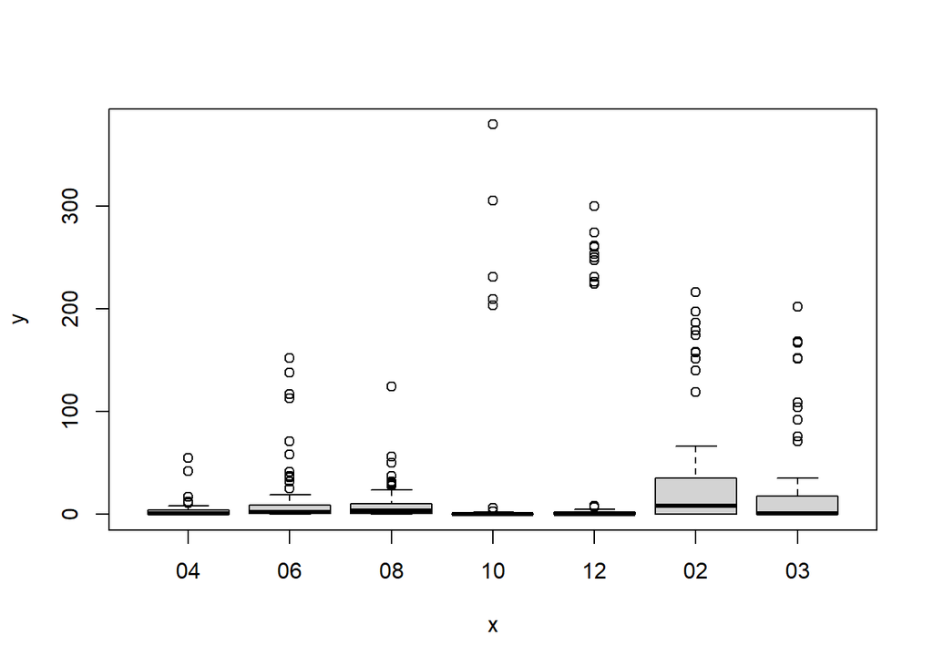

```r
with(preytotal, plot(month, total))
```

```r
preyden <- preytotal %>%
  group_by(Date, Site, tod, siteTODMonth) %>%
  summarise_at(.vars = vars(total),
               .funs = c(den="mean"))

preyden <- preyden %>%
  mutate(logden=log(den+1))
```

Join benthic prey and shorebird count data; prepare for abundance modelling:

Calculate mean and site-centred values for benthic prey density.

```r
shorecountsprey <- left_join(shorecounts, preyden)

shorecountsprey <- shorecountsprey %>%
  group_by(Site) %>%
  mutate(avgprey = mean(logden)) %>%
  mutate(prey.c = as.vector(scale(logden, scale = TRUE)))%>%
  ungroup()
```

Model total abundance, Red-necked Stint and Red-capped Plover abundance with month, time of day and a month by time of day interaction term as explanatory variables, and site and a site by month interaction term as random effects. Try with Poisson distribution and use negative binomial if overdispersed.

Plot modelled estimates for month and time of day.

```r
glmmpoimonthnull <- glmmTMB(shoreabun ~ 1 + (1|Site) + (1|siteMonth), data = shorecountsprey, family = poisson)
summary(glmmpoimonthnull)
```

```
##  Family: poisson  ( log )
## Formula:          shoreabun ~ 1 + (1 | Site) + (1 | siteMonth)
## Data: shorecountsprey
##
##      AIC      BIC   logLik deviance df.resid
##   2752.2   2759.7  -1373.1   2746.2       86
##
## Random effects:
##
## Conditional model:
##  Groups    Name        Variance Std.Dev.
##  Site      (Intercept) 1.317    1.148
##  siteMonth (Intercept) 1.888    1.374
## Number of obs: 89, groups:  Site, 7; siteMonth, 46
##
## Conditional model:
##             Estimate Std. Error z value Pr(>|z|)
## (Intercept)   2.5659     0.4829   5.313 1.08e-07 ***
## ---
## Signif. codes:  0 '***' 0.001 '**' 0.01 '*' 0.05 '.' 0.1 ' ' 1
```

```r
car::Anova(glmmpoimonthnull)
```

```
## Analysis of Deviance Table (Type II Wald chisquare tests)
##
## Response: shoreabun
##      Chisq Df Pr(>Chisq)
```

```r
performance::check_overdispersion(glmmpoimonthnull)
```

```
## # Overdispersion test
##
##        dispersion ratio =   21.730
##   Pearson's Chi-Squared = 1868.811
##                 p-value =  < 0.001
```

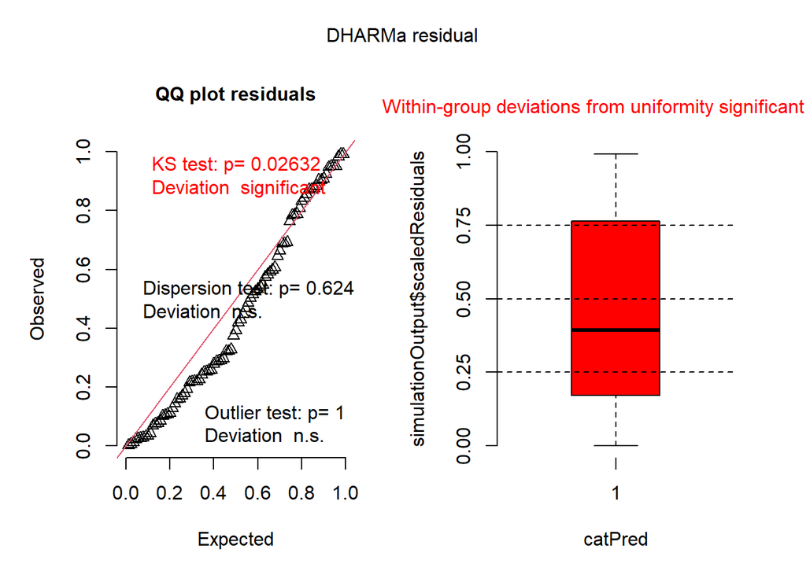

```r
plot(simres <- simulateResiduals(glmmpoimonthnull))
```

```r
glmmmonthnull_total <- glmmTMB(shoreabun ~ 1 + (1|Site) + (1|siteMonth), data = shorecountsprey, family = 'nbinom2')
summary(glmmmonthnull_total)
```

```
##  Family: nbinom2  ( log )
## Formula:          shoreabun ~ 1 + (1 | Site) + (1 | siteMonth)
## Data: shorecountsprey
##
##      AIC      BIC   logLik deviance df.resid
##    761.4    771.4   -376.7    753.4       85
##
## Random effects:
##
## Conditional model:
##  Groups    Name        Variance Std.Dev.
##  Site      (Intercept) 1.299    1.1397
##  siteMonth (Intercept) 0.848    0.9209
## Number of obs: 89, groups:  Site, 7; siteMonth, 46
##
## Dispersion parameter for nbinom2 family (): 0.659
##
## Conditional model:
##             Estimate Std. Error z value Pr(>|z|)
## (Intercept)   2.9781     0.4882     6.1 1.06e-09 ***
## ---
## Signif. codes:  0 '***' 0.001 '**' 0.01 '*' 0.05 '.' 0.1 ' ' 1
```

```r
car::Anova(glmmmonthnull_total)
```

```
## Analysis of Deviance Table (Type II Wald chisquare tests)
##
## Response: shoreabun
##      Chisq Df Pr(>Chisq)
```

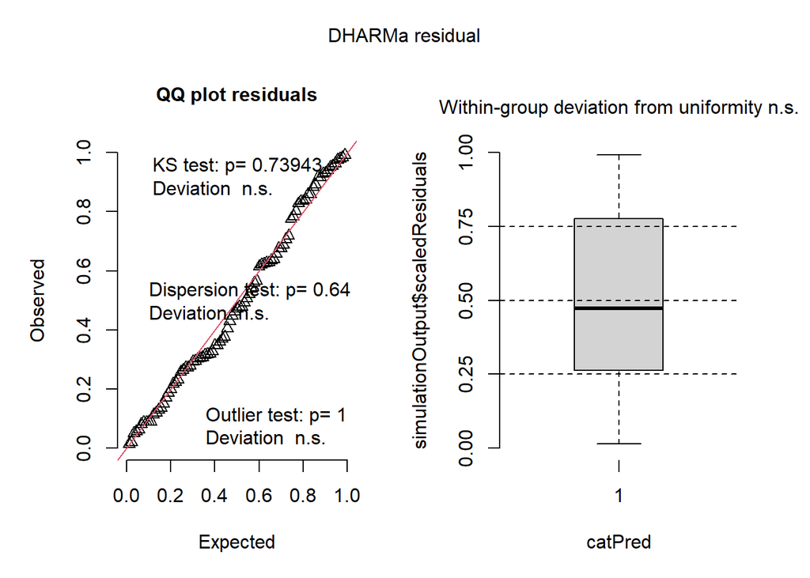

```r
plot(simres <- simulateResiduals(glmmmonthnull_total))
```

```r
glmmmonth_total <- glmmTMB(shoreabun ~ tod + month + month*tod +
                       (1|Site) + (1|siteMonth),
                     data = shorecountsprey, family = 'nbinom2')
summary(glmmmonth_total)
```

```
##  Family: nbinom2  ( log )
## Formula:
## shoreabun ~ tod + month + month * tod + (1 | Site) + (1 | siteMonth)
## Data: shorecountsprey
##
##      AIC      BIC   logLik deviance df.resid
##    761.3    803.6   -363.7    727.3       72
##
## Random effects:
##
## Conditional model:
##  Groups    Name        Variance Std.Dev.
##  Site      (Intercept) 1.4088   1.1869
##  siteMonth (Intercept) 0.2075   0.4556
## Number of obs: 89, groups:  Site, 7; siteMonth, 46
##
## Dispersion parameter for nbinom2 family (): 0.747
##
## Conditional model:
##               Estimate Std. Error z value Pr(>|z|)
## (Intercept)     4.0460     0.7270   5.566 2.61e-08 ***
## todpm          -1.0694     0.7727  -1.384 0.166371
## month06        -0.9248     0.7943  -1.164 0.244336
## month08        -2.9847     0.8375  -3.564 0.000366 ***
## month10        -0.9009     0.7863  -1.146 0.251940
## month12         0.3831     0.7820   0.490 0.624235
## month02        -0.9677     0.7530  -1.285 0.198747
## month03        -1.3797     0.7714  -1.789 0.073677 .
## todpm:month06   0.2278     1.0812   0.211 0.833132
## todpm:month08   1.4806     1.1763   1.259 0.208148
## todpm:month10   0.1794     1.1371   0.158 0.874634
## todpm:month12   0.5263     1.0206   0.516 0.606107
## todpm:month02   1.3905     1.0976   1.267 0.205218
## todpm:month03   0.4707     1.0444   0.451 0.652182
## ---
## Signif. codes:  0 '***' 0.001 '**' 0.01 '*' 0.05 '.' 0.1 ' ' 1
```

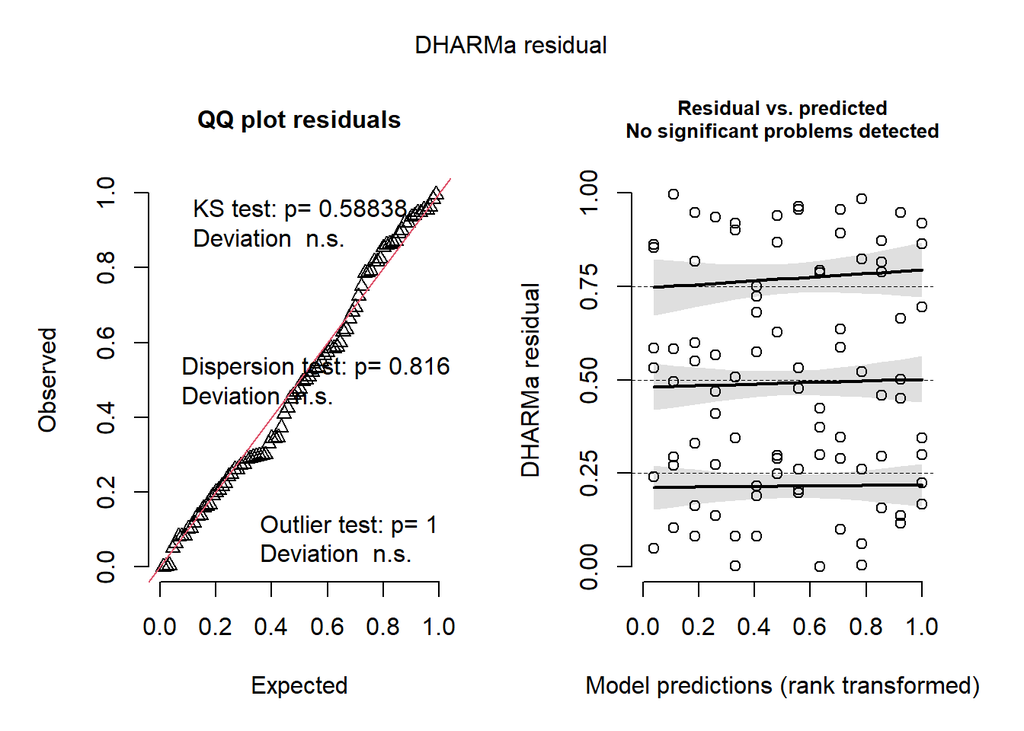

```r
plot(simres <- simulateResiduals(glmmmonth_total))
```

```r
car::Anova(glmmmonth_total)
```

```
## Analysis of Deviance Table (Type II Wald chisquare tests)
##
## Response: shoreabun
##             Chisq Df Pr(>Chisq)
## tod        2.6464  1  0.1037870
## month     27.6102  6  0.0001112 ***
## tod:month  3.1265  6  0.7928166
## ---
## Signif. codes:  0 '***' 0.001 '**' 0.01 '*' 0.05 '.' 0.1 ' ' 1
```

```r
testZeroInflation(simres, plot = FALSE)
```

```
##
##  DHARMa zero-inflation test via comparison to expected zeros with
##  simulation under H0 = fitted model
##
## data:  simulationOutput
## ratioObsSim = 1.1301, p-value = 0.688
## alternative hypothesis: two.sided
```

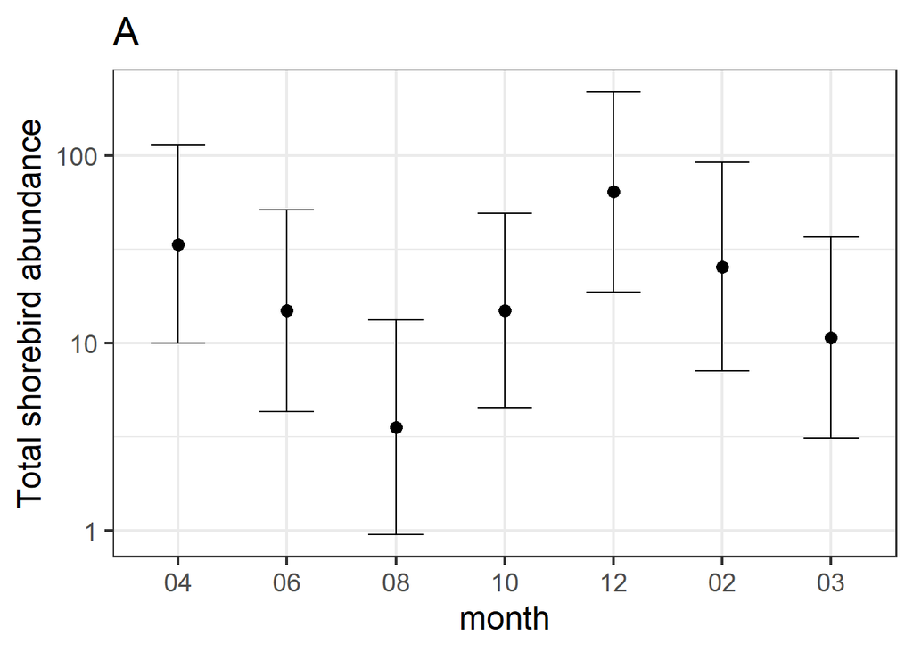

```r
month.model.est_total <- as.data.frame(emmeans(glmmmonth_total, specs = "month"))
tod.model.est_total <- as.data.frame(emmeans(glmmmonth_total, specs = "tod"))

pd <- position_dodge(width = 0.5)

plotmonth_total <- ggplot(month.model.est_total, aes(x = month, y = emmean)) +
  geom_point(size = 3, position = pd) + geom_errorbar(aes(ymin = lower.CL, ymax = upper.CL), width = 0.5, position = pd) +
  scale_y_continuous(breaks = log(c(0.01, 0.1, 1, 10, 100, 1000)), labels = c(0.01, 0.1, 1, 10, 100, 1000)) +
  theme_bw(base_size = 18) +
  labs(y = "Total shorebird abundance") +
  ggtitle("A")
plotmonth_total
```

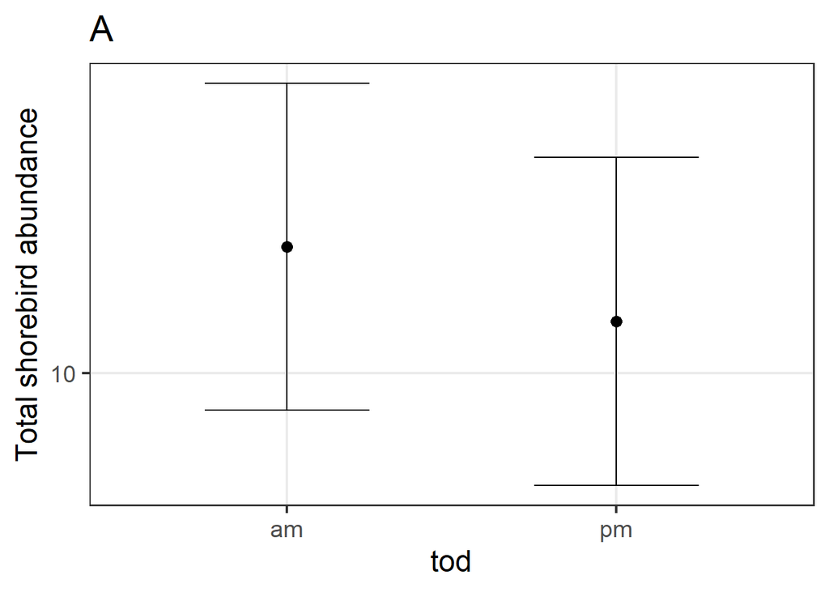

```r
ggsave("./03_plots/plotmonth_total.png", plot = plotmonth_total, width = 6, height = 6, dpi = 300)


plottod_total <- ggplot(tod.model.est_total, aes(x = tod, y = emmean)) +
  geom_point(size = 3, position = pd) + geom_errorbar(aes(ymin = lower.CL, ymax = upper.CL), width = 0.5, position = pd) +
  scale_y_continuous(breaks = log(c(0.01, 0.1, 1, 10, 100, 1000)), labels = c(0.01, 0.1, 1, 10, 100, 1000)) +
  theme_bw(base_size = 18) +
  labs(y = "Total shorebird abundance")+
  ggtitle("A")
plottod_total
```

```r
ggsave("./03_plots/plottod_total.png", plot = plottod_total, width = 6, height = 6, dpi = 300)

glmmpoimonthnull <- glmmTMB(RedneckedStint ~ 1 + (1|Site) + (1|siteMonth), data = shorecountsprey, family = poisson)
summary(glmmpoimonthnull)
```

```
##  Family: poisson  ( log )
## Formula:          RedneckedStint ~ 1 + (1 | Site) + (1 | siteMonth)
## Data: shorecountsprey
##
##      AIC      BIC   logLik deviance df.resid
##   2840.8   2848.3  -1417.4   2834.8       86
##
## Random effects:
##
## Conditional model:
##  Groups    Name        Variance Std.Dev.
##  Site      (Intercept) 4.774    2.185
##  siteMonth (Intercept) 7.137    2.672
## Number of obs: 89, groups:  Site, 7; siteMonth, 46
##
## Conditional model:
##             Estimate Std. Error z value Pr(>|z|)
## (Intercept)  0.05352    0.98796   0.054    0.957
```

```r
car::Anova(glmmpoimonthnull)
```

```
## Analysis of Deviance Table (Type II Wald chisquare tests)
##
## Response: RedneckedStint
##      Chisq Df Pr(>Chisq)
```

```r
performance::check_overdispersion(glmmpoimonthnull)
```

```
## # Overdispersion test
##
##        dispersion ratio =   23.510
##   Pearson's Chi-Squared = 2021.884
##                 p-value =  < 0.001
```

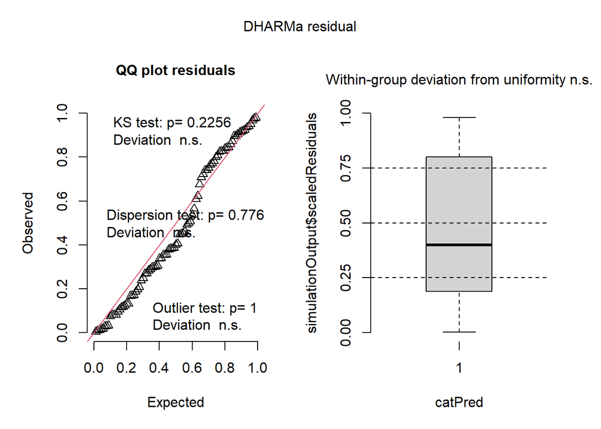

```r
plot(simres <- simulateResiduals(glmmpoimonthnull))
```

```r
glmmmonthnull_REST <- glmmTMB(RedneckedStint ~ 1 + (1|Site) + (1|siteMonth), data = shorecountsprey, family = 'nbinom2')
summary(glmmmonthnull_REST)
```

```
##  Family: nbinom2  ( log )
## Formula:          RedneckedStint ~ 1 + (1 | Site) + (1 | siteMonth)
## Data: shorecountsprey
##
##      AIC      BIC   logLik deviance df.resid
##    520.8    530.8   -256.4    512.8       85
##
## Random effects:
##
## Conditional model:
##  Groups    Name        Variance Std.Dev.
##  Site      (Intercept) 2.841    1.685
##  siteMonth (Intercept) 2.015    1.419
## Number of obs: 89, groups:  Site, 7; siteMonth, 46
##
## Dispersion parameter for nbinom2 family (): 0.179
##
## Conditional model:
##             Estimate Std. Error z value Pr(>|z|)
## (Intercept)     2.00       0.89   2.247   0.0247 *
## ---
## Signif. codes:  0 '***' 0.001 '**' 0.01 '*' 0.05 '.' 0.1 ' ' 1
```

```r
car::Anova(glmmmonthnull_REST)
```

```
## Analysis of Deviance Table (Type II Wald chisquare tests)
##
## Response: RedneckedStint
##      Chisq Df Pr(>Chisq)
```

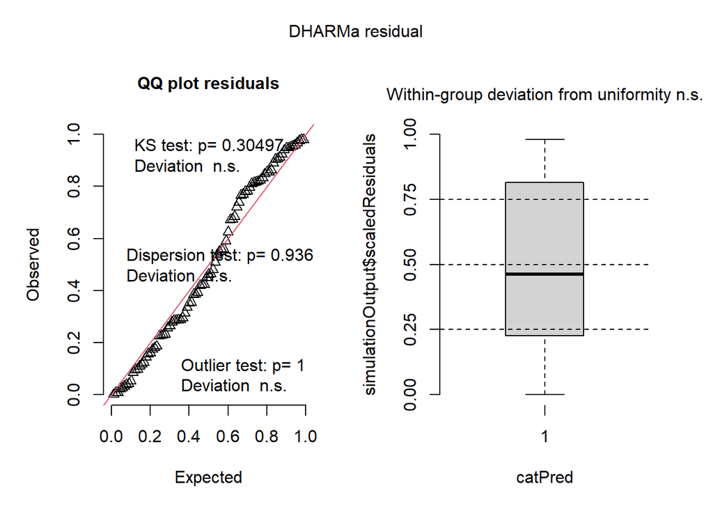

```r
plot(simres <- simulateResiduals(glmmmonthnull_REST))
```

```r
glmmmonth_REST <- glmmTMB(RedneckedStint ~ tod + month + month*tod +
                       (1|Site) + (1|siteMonth),
                     data = shorecountsprey, family = 'nbinom2')
summary(glmmmonth_REST)
```

```
##  Family: nbinom2  ( log )
## Formula:
## RedneckedStint ~ tod + month + month * tod + (1 | Site) + (1 |      siteMonth)
## Data: shorecountsprey
##
##      AIC      BIC   logLik deviance df.resid
##    521.8    564.1   -243.9    487.8       72
##
## Random effects:
##
## Conditional model:
##  Groups    Name        Variance  Std.Dev.
##  Site      (Intercept) 4.287e+00 2.0704649
##  siteMonth (Intercept) 1.066e-08 0.0001032
## Number of obs: 89, groups:  Site, 7; siteMonth, 46
##
## Dispersion parameter for nbinom2 family (): 0.226
##
## Conditional model:
##               Estimate Std. Error z value Pr(>|z|)
## (Intercept)     4.1318     1.2962   3.188 0.001435 **
## todpm          -2.9699     1.4928  -1.990 0.046643 *
## month06        -3.6594     1.4158  -2.585 0.009748 **
## month08        -5.8188     1.7136  -3.396 0.000684 ***
## month10        -2.5564     1.4059  -1.818 0.069009 .
## month12         0.3954     1.4967   0.264 0.791618
## month02        -2.6274     1.3966  -1.881 0.059933 .
## month03        -1.1334     1.3074  -0.867 0.385994
## todpm:month06   1.5231     2.1275   0.716 0.474040
## todpm:month08   4.9890     2.2759   2.192 0.028368 *
## todpm:month10   1.1827     2.0467   0.578 0.563343
## todpm:month12   2.5680     2.0076   1.279 0.200848
## todpm:month02   3.6703     2.0344   1.804 0.071219 .
## todpm:month03   1.2206     2.1788   0.560 0.575335
## ---
## Signif. codes:  0 '***' 0.001 '**' 0.01 '*' 0.05 '.' 0.1 ' ' 1
```

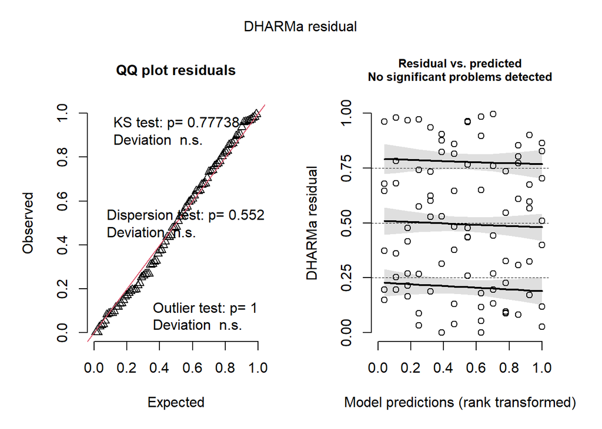

```r
plot(simres <- simulateResiduals(glmmmonth_REST))
```

```r
car::Anova(glmmmonth_REST)
```

```
## Analysis of Deviance Table (Type II Wald chisquare tests)
##
## Response: RedneckedStint
##             Chisq Df Pr(>Chisq)
## tod        1.2104  1  0.2712486
## month     26.0272  6  0.0002201 ***
## tod:month  7.6230  6  0.2670453
## ---
## Signif. codes:  0 '***' 0.001 '**' 0.01 '*' 0.05 '.' 0.1 ' ' 1
```

```r
testZeroInflation(simres, plot = FALSE)
```

```
##
##  DHARMa zero-inflation test via comparison to expected zeros with
##  simulation under H0 = fitted model
##
## data:  simulationOutput
## ratioObsSim = 1.0604, p-value = 0.736
## alternative hypothesis: two.sided
```

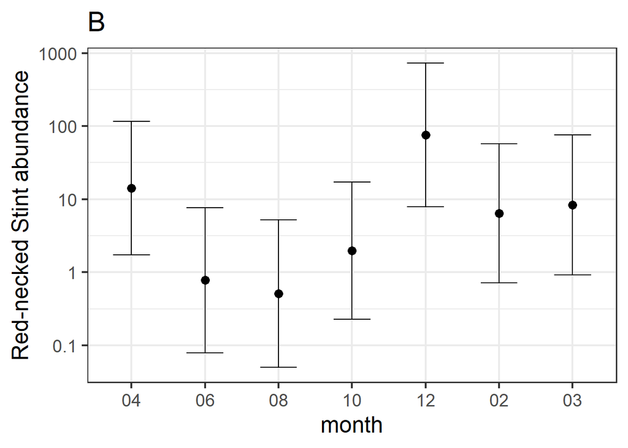

```r
month.model.est_REST <- as.data.frame(emmeans(glmmmonth_REST, specs = "month"))
tod.model.est_REST <- as.data.frame(emmeans(glmmmonth_REST, specs = "tod"))

pd <- position_dodge(width = 0.5)

plotmonth_REST <- ggplot(month.model.est_REST, aes(x = month, y = emmean)) +
  geom_point(size = 3, position = pd) + geom_errorbar(aes(ymin = lower.CL, ymax = upper.CL), width = 0.5, position = pd) +
  scale_y_continuous(breaks = log(c(0.01, 0.1, 1, 10, 100, 1000)), labels = c(0.01, 0.1, 1, 10, 100, 1000)) +
  theme_bw(base_size = 18) +
  labs(y = "Red-necked Stint abundance") +
  ggtitle("B")
plotmonth_REST
```

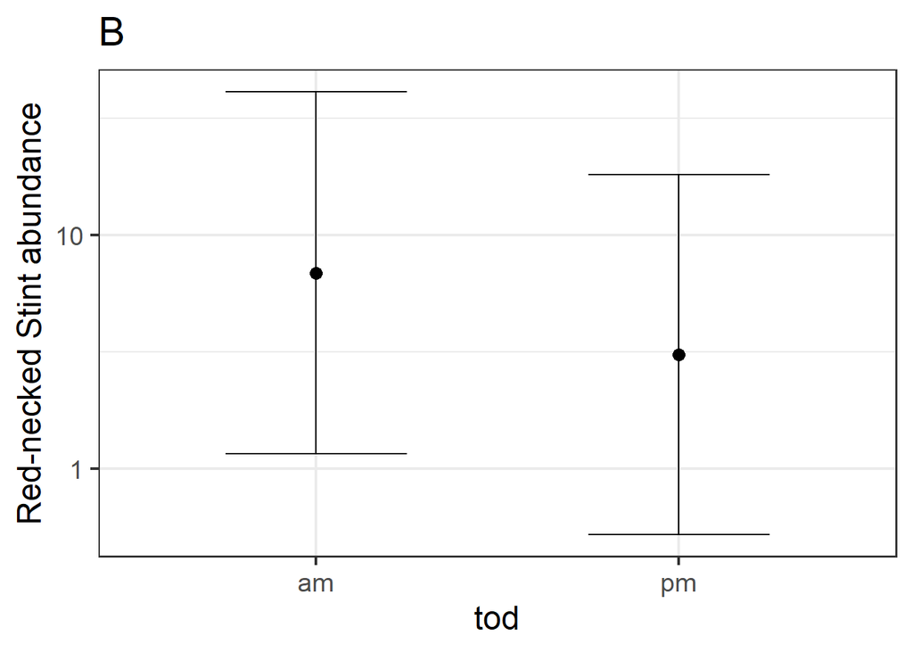

```r
ggsave("./03_plots/plotmonth_REST.png", plot = plotmonth_REST, width = 6, height = 6, dpi = 300)


plottod_REST <- ggplot(tod.model.est_REST, aes(x = tod, y = emmean)) +
  geom_point(size = 3, position = pd) + geom_errorbar(aes(ymin = lower.CL, ymax = upper.CL), width = 0.5, position = pd) +
  scale_y_continuous(breaks = log(c(0.01, 0.1, 1, 10, 100, 1000)), labels = c(0.01, 0.1, 1, 10, 100, 1000)) +
  theme_bw(base_size = 18) +
  labs(y = "Red-necked Stint abundance")+
  ggtitle("B")
plottod_REST
```

```r
ggsave("./03_plots/plottod_REST.png", plot = plottod_REST, width = 6, height = 6, dpi = 300)

glmmpoimonthnull <- glmmTMB(RedcappedPlover ~ 1 + (1|Site) + (1|siteMonth), data = shorecountsprey, family = poisson)
summary(glmmpoimonthnull)
```

```
##  Family: poisson  ( log )
## Formula:          RedcappedPlover ~ 1 + (1 | Site) + (1 | siteMonth)
## Data: shorecountsprey
##
##      AIC      BIC   logLik deviance df.resid
##    625.2    632.6   -309.6    619.2       86
##
## Random effects:
##
## Conditional model:
##  Groups    Name        Variance Std.Dev.
##  Site      (Intercept) 2.948    1.717
##  siteMonth (Intercept) 2.827    1.681
## Number of obs: 89, groups:  Site, 7; siteMonth, 46
##
## Conditional model:
##             Estimate Std. Error z value Pr(>|z|)
## (Intercept)  -0.1976     0.7423  -0.266     0.79
```

```r
car::Anova(glmmpoimonthnull)
```

```
## Analysis of Deviance Table (Type II Wald chisquare tests)
##
## Response: RedcappedPlover
##      Chisq Df Pr(>Chisq)
```

```r
performance::check_overdispersion(glmmpoimonthnull)
```

```
## # Overdispersion test
##
##        dispersion ratio =   3.082
##   Pearson's Chi-Squared = 265.074
##                 p-value = < 0.001
```

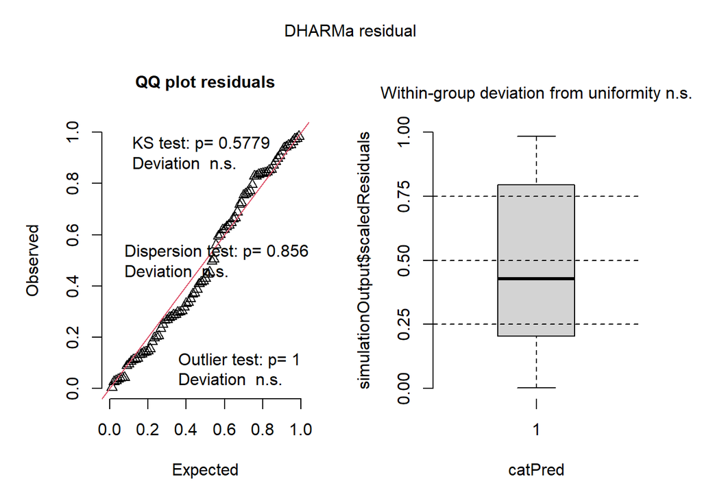

```r
plot(simres <- simulateResiduals(glmmpoimonthnull))
```

```r
glmmmonthnull_REPL <- glmmTMB(RedcappedPlover ~ 1 + (1|Site) + (1|siteMonth), data = shorecountsprey, family = 'nbinom2')
summary(glmmmonthnull_REPL)
```

```
##  Family: nbinom2  ( log )
## Formula:          RedcappedPlover ~ 1 + (1 | Site) + (1 | siteMonth)
## Data: shorecountsprey
##
##      AIC      BIC   logLik deviance df.resid
##    403.1    413.1   -197.6    395.1       85
##
## Random effects:
##
## Conditional model:
##  Groups    Name        Variance Std.Dev.
##  Site      (Intercept) 2.924    1.710
##  siteMonth (Intercept) 1.759    1.326
## Number of obs: 89, groups:  Site, 7; siteMonth, 46
##
## Dispersion parameter for nbinom2 family (): 0.781
##
## Conditional model:
##             Estimate Std. Error z value Pr(>|z|)
## (Intercept)   0.2026     0.7637   0.265    0.791
```

```r
car::Anova(glmmmonthnull_REPL)
```

```
## Analysis of Deviance Table (Type II Wald chisquare tests)
##
## Response: RedcappedPlover
##      Chisq Df Pr(>Chisq)
```

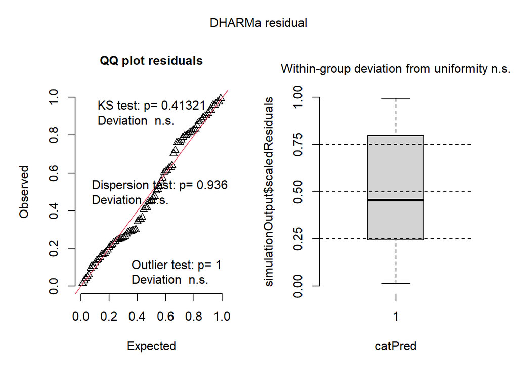

```r
plot(simres <- simulateResiduals(glmmmonthnull_REPL))
```

```r
glmmmonth_REPL <- glmmTMB(RedcappedPlover ~ tod + month + month*tod +
                       (1|Site) + (1|siteMonth),
                     data = shorecountsprey, family = 'nbinom2')
summary(glmmmonth_REPL)
```

```
##  Family: nbinom2  ( log )
## Formula:
## RedcappedPlover ~ tod + month + month * tod + (1 | Site) + (1 |      siteMonth)
## Data: shorecountsprey
##
##      AIC      BIC   logLik deviance df.resid
##    403.2    445.5   -184.6    369.2       72
##
## Random effects:
##
## Conditional model:
##  Groups    Name        Variance  Std.Dev.
##  Site      (Intercept) 3.192e+00 1.7866650
##  siteMonth (Intercept) 1.558e-08 0.0001248
## Number of obs: 89, groups:  Site, 7; siteMonth, 46
##
## Dispersion parameter for nbinom2 family (): 0.634
##
## Conditional model:
##               Estimate Std. Error z value Pr(>|z|)
## (Intercept)     1.7353     0.9372   1.852  0.06409 .
## todpm          -0.5551     0.9330  -0.595  0.55190
## month06        -0.6780     0.9141  -0.742  0.45828
## month08        -3.0845     1.0460  -2.949  0.00319 **
## month10        -2.3630     0.9722  -2.431  0.01507 *
## month12        -0.5155     0.8674  -0.594  0.55226
## month02         0.2905     0.8773   0.331  0.74058
## month03        -0.8658     0.8456  -1.024  0.30590
## todpm:month06  -1.8956     1.4611  -1.297  0.19450
## todpm:month08   0.6568     1.4149   0.464  0.64250
## todpm:month10  -0.4716     1.4019  -0.336  0.73656
## todpm:month12   0.4009     1.3109   0.306  0.75976
## todpm:month02  -0.9411     1.2525  -0.751  0.45242
## todpm:month03   0.3288     1.2644   0.260  0.79480
## ---
## Signif. codes:  0 '***' 0.001 '**' 0.01 '*' 0.05 '.' 0.1 ' ' 1
```

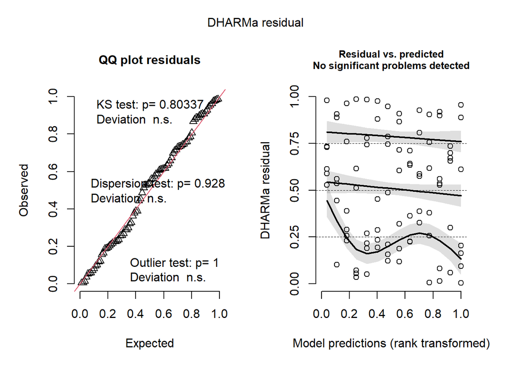

```r
plot(simres <- simulateResiduals(glmmmonth_REPL))
```

```r
car::Anova(glmmmonth_REPL)
```

```
## Analysis of Deviance Table (Type II Wald chisquare tests)
##
## Response: RedcappedPlover
##             Chisq Df Pr(>Chisq)
## tod        4.8711  1  0.0273099 *
## month     27.2628  6  0.0001293 ***
## tod:month  4.6915  6  0.5839435
## ---
## Signif. codes:  0 '***' 0.001 '**' 0.01 '*' 0.05 '.' 0.1 ' ' 1
```

```r
testZeroInflation(simres, plot = FALSE)
```

```
##
##  DHARMa zero-inflation test via comparison to expected zeros with
##  simulation under H0 = fitted model
##
## data:  simulationOutput
## ratioObsSim = 1.0674, p-value = 0.76
## alternative hypothesis: two.sided
```

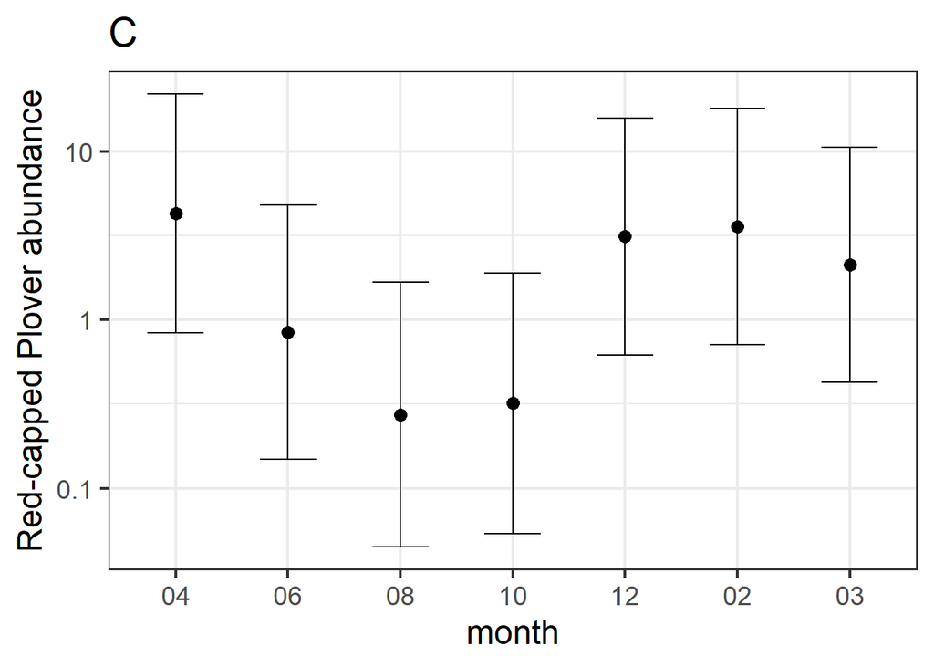

```r
month.model.est_REPL <- as.data.frame(emmeans(glmmmonth_REPL, specs = "month"))
tod.model.est_REPL <- as.data.frame(emmeans(glmmmonth_REPL, specs = "tod"))

pd <- position_dodge(width = 0.5)

plotmonth_REPL <- ggplot(month.model.est_REPL, aes(x = month, y = emmean)) +
  geom_point(size = 3, position = pd) + geom_errorbar(aes(ymin = lower.CL, ymax = upper.CL), width = 0.5, position = pd) +
  scale_y_continuous(breaks = log(c(0.01, 0.1, 1, 10, 100, 1000)), labels = c(0.01, 0.1, 1, 10, 100, 1000)) +
  theme_bw(base_size = 18) +
  labs(y = "Red-capped Plover abundance") +
  ggtitle("C")
plotmonth_REPL
```

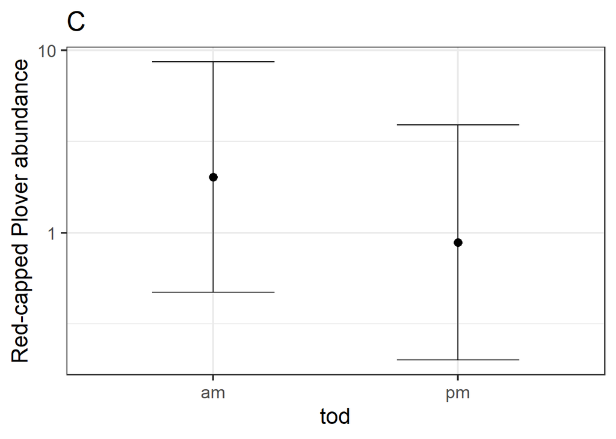

```r
ggsave("./03_plots/plotmonth_REPL.png", plot = plotmonth_REPL, width = 6, height = 6, dpi = 300)


plottod_REPL <- ggplot(tod.model.est_REPL, aes(x = tod, y = emmean)) +
  geom_point(size = 3, position = pd) + geom_errorbar(aes(ymin = lower.CL, ymax = upper.CL), width = 0.5, position = pd) +
  scale_y_continuous(breaks = log(c(0.01, 0.1, 1, 10, 100, 1000)), labels = c(0.01, 0.1, 1, 10, 100, 1000)) +
  theme_bw(base_size = 18) +
  labs(y = "Red-capped Plover abundance") +
  ggtitle("C")
plottod_REPL
```

```r
ggsave("./03_plots/plottod_REPL.png", plot = plottod_REPL, width = 6, height = 6, dpi = 300)
```

Model site-level total shorebird abundance.

Fit the null model and a model with time-of-day as the explanatory variable and check for overdispersion using a Poisson distribution.

```r
glmmnull_poi_total <- glmmTMB(shoreabun ~ 1 + (1|Site) + (1|month) + (1|siteMonth), data = shorecountsprey, family = poisson)
summary(glmmnull_poi_total)
```

```
##  Family: poisson  ( log )
## Formula:          shoreabun ~ 1 + (1 | Site) + (1 | month) + (1 | siteMonth)
## Data: shorecountsprey
##
##      AIC      BIC   logLik deviance df.resid
##   2747.7   2757.7  -1369.8   2739.7       85
##
## Random effects:
##
## Conditional model:
##  Groups    Name        Variance Std.Dev.
##  Site      (Intercept) 1.4730   1.2137
##  month     (Intercept) 0.6215   0.7883
##  siteMonth (Intercept) 1.2438   1.1153
## Number of obs: 89, groups:  Site, 7; month, 7; siteMonth, 46
##
## Conditional model:
##             Estimate Std. Error z value Pr(>|z|)
## (Intercept)   2.5426     0.5748   4.423 9.71e-06 ***
## ---
## Signif. codes:  0 '***' 0.001 '**' 0.01 '*' 0.05 '.' 0.1 ' ' 1
```

```r
car::Anova(glmmnull_poi_total)
```

```
## Analysis of Deviance Table (Type II Wald chisquare tests)
##
## Response: shoreabun
##      Chisq Df Pr(>Chisq)
```

```r
performance::check_overdispersion(glmmnull_poi_total)
```

```
## # Overdispersion test
##
##        dispersion ratio =   22.007
##   Pearson's Chi-Squared = 1870.572
##                 p-value =  < 0.001
```

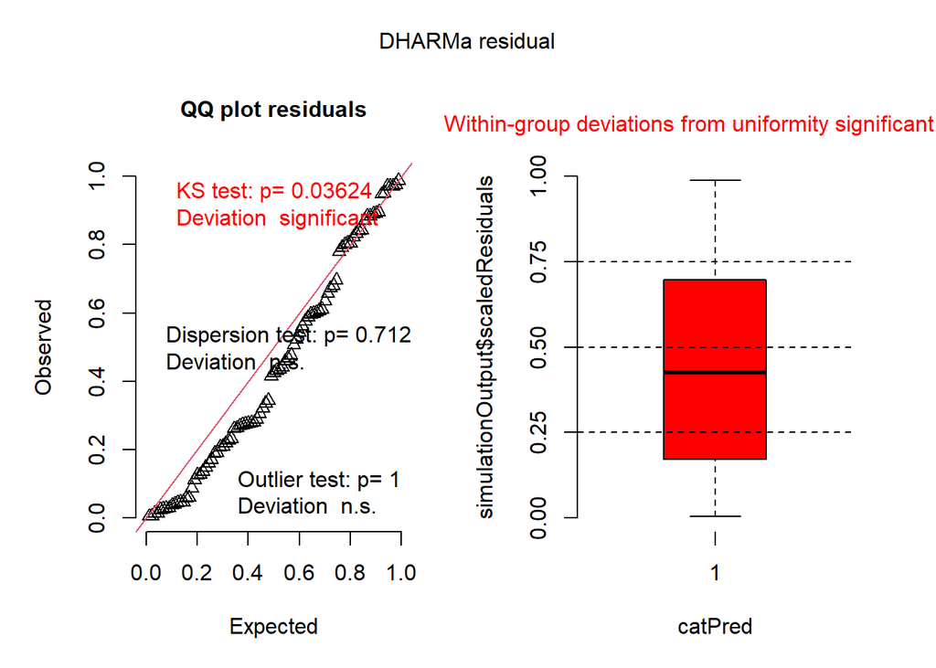

```r
plot(simres <- simulateResiduals(glmmnull_poi_total))
```

```r
glmmtod_poi_total <- glmmTMB(shoreabun ~ tod + (1|Site) + (1|month) + (1|siteMonth), data = shorecountsprey, family = poisson)
summary(glmmtod_poi_total)
```

```
##  Family: poisson  ( log )
## Formula:          shoreabun ~ tod + (1 | Site) + (1 | month) + (1 | siteMonth)
## Data: shorecountsprey
##
##      AIC      BIC   logLik deviance df.resid
##   2644.9   2657.3  -1317.4   2634.9       84
##
## Random effects:
##
## Conditional model:
##  Groups    Name        Variance Std.Dev.
##  Site      (Intercept) 1.4754   1.215
##  month     (Intercept) 0.6146   0.784
##  siteMonth (Intercept) 1.2451   1.116
## Number of obs: 89, groups:  Site, 7; month, 7; siteMonth, 46
##
## Conditional model:
##             Estimate Std. Error z value Pr(>|z|)
## (Intercept)  2.66504    0.57439    4.64 3.49e-06 ***
## todpm       -0.28840    0.02832  -10.18  < 2e-16 ***
## ---
## Signif. codes:  0 '***' 0.001 '**' 0.01 '*' 0.05 '.' 0.1 ' ' 1
```

```r
car::Anova(glmmtod_poi_total)
```

```
## Analysis of Deviance Table (Type II Wald chisquare tests)
##
## Response: shoreabun
##      Chisq Df Pr(>Chisq)
## tod 103.71  1  < 2.2e-16 ***
## ---
## Signif. codes:  0 '***' 0.001 '**' 0.01 '*' 0.05 '.' 0.1 ' ' 1
```

```r
performance::check_overdispersion(glmmtod_poi_total)
```

```
## # Overdispersion test
##
##        dispersion ratio =   21.461
##   Pearson's Chi-Squared = 1802.710
##                 p-value =  < 0.001
```

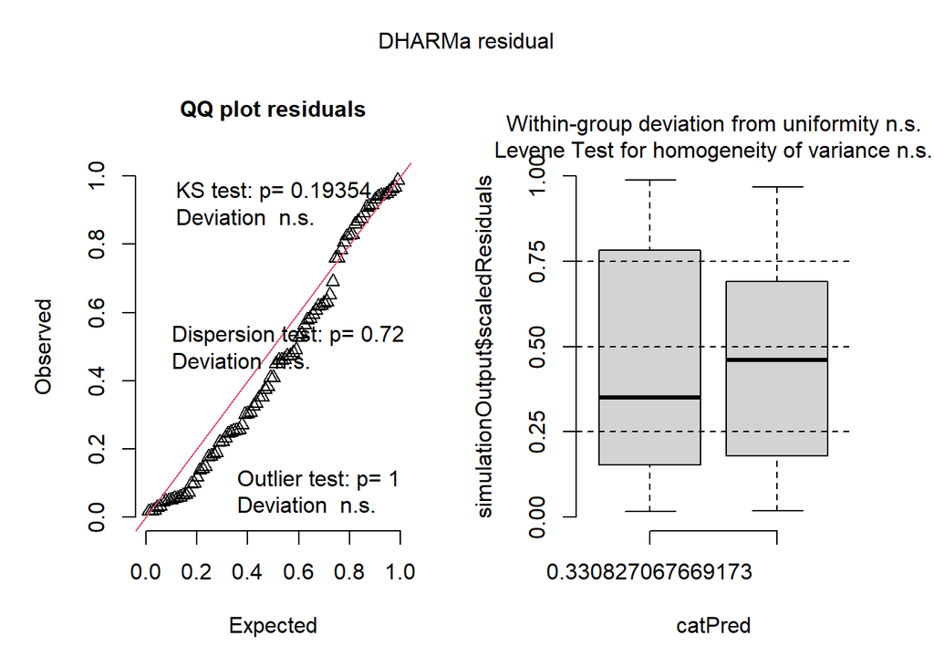

```r
plot(simres <- simulateResiduals(glmmtod_poi_total))
```

Overdispersed, so use negative binomial distribution instead.

```r
glmmnull_nb_total <- glmmTMB(shoreabun ~ 1 + (1|Site) + (1|month) + (1|siteMonth), data = shorecountsprey, family = 'nbinom2')
summary(glmmnull_nb_total)
```

```
##  Family: nbinom2  ( log )
## Formula:          shoreabun ~ 1 + (1 | Site) + (1 | month) + (1 | siteMonth)
## Data: shorecountsprey
##
##      AIC      BIC   logLik deviance df.resid
##    758.0    770.4   -374.0    748.0       84
##
## Random effects:
##
## Conditional model:
##  Groups    Name        Variance Std.Dev.
##  Site      (Intercept) 1.4409   1.2004
##  month     (Intercept) 0.5743   0.7578
##  siteMonth (Intercept) 0.4800   0.6928
## Number of obs: 89, groups:  Site, 7; month, 7; siteMonth, 46
##
## Dispersion parameter for nbinom2 family (): 0.708
##
## Conditional model:
##             Estimate Std. Error z value Pr(>|z|)
## (Intercept)   2.9060     0.5729   5.073 3.92e-07 ***
## ---
## Signif. codes:  0 '***' 0.001 '**' 0.01 '*' 0.05 '.' 0.1 ' ' 1
```

```r
car::Anova(glmmnull_nb_total)
```

```
## Analysis of Deviance Table (Type II Wald chisquare tests)
##
## Response: shoreabun
##      Chisq Df Pr(>Chisq)
```

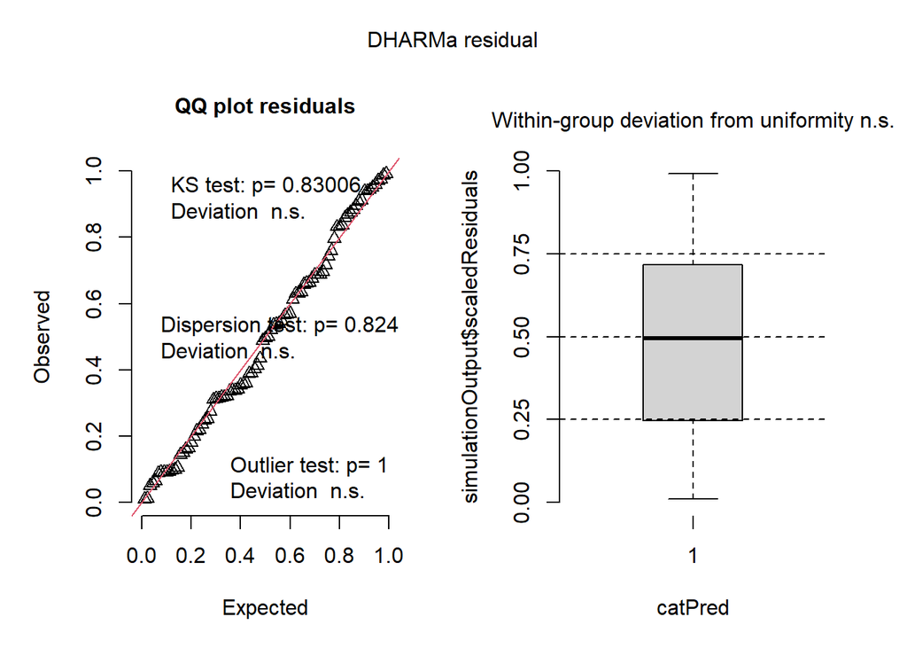

```r
plot(simres <- simulateResiduals(glmmnull_nb_total))
```

```r
testZeroInflation(simres, plot = FALSE)
```

```
##
##  DHARMa zero-inflation test via comparison to expected zeros with
##  simulation under H0 = fitted model
##
## data:  simulationOutput
## ratioObsSim = 1.1003, p-value = 0.792
## alternative hypothesis: two.sided
```

```r
glmmtod_nb_total <- glmmTMB(shoreabun ~ tod + (1|Site) + (1|month) + (1|siteMonth), data = shorecountsprey, family = 'nbinom2')
summary(glmmtod_nb_total)
```

```
##  Family: nbinom2  ( log )
## Formula:          shoreabun ~ tod + (1 | Site) + (1 | month) + (1 | siteMonth)
## Data: shorecountsprey
##
##      AIC      BIC   logLik deviance df.resid
##    757.3    772.2   -372.7    745.3       83
##
## Random effects:
##
## Conditional model:
##  Groups    Name        Variance Std.Dev.
##  Site      (Intercept) 1.4952   1.2228
##  month     (Intercept) 0.5400   0.7349
##  siteMonth (Intercept) 0.4771   0.6907
## Number of obs: 89, groups:  Site, 7; month, 7; siteMonth, 46
##
## Dispersion parameter for nbinom2 family (): 0.734
##
## Conditional model:
##             Estimate Std. Error z value Pr(>|z|)
## (Intercept)   3.1173     0.5929   5.258 1.46e-07 ***
## todpm        -0.4900     0.2959  -1.656   0.0978 .
## ---
## Signif. codes:  0 '***' 0.001 '**' 0.01 '*' 0.05 '.' 0.1 ' ' 1
```

```r
car::Anova(glmmtod_nb_total)
```

```
## Analysis of Deviance Table (Type II Wald chisquare tests)
##
## Response: shoreabun
##      Chisq Df Pr(>Chisq)
## tod 2.7418  1    0.09776 .
## ---
## Signif. codes:  0 '***' 0.001 '**' 0.01 '*' 0.05 '.' 0.1 ' ' 1
```

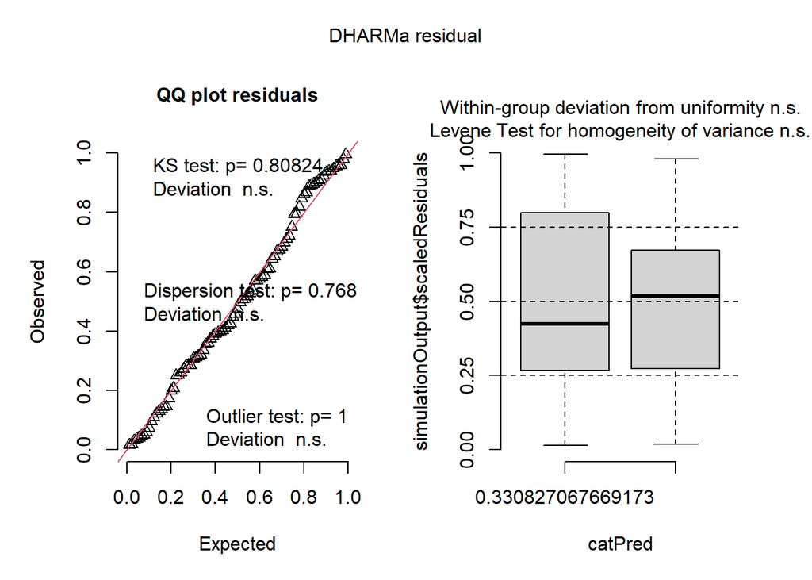

```r
plot(simres <- simulateResiduals(glmmtod_nb_total))
```

```r
testZeroInflation(simres, plot = FALSE)
```

```
##
##  DHARMa zero-inflation test via comparison to expected zeros with
##  simulation under H0 = fitted model
##
## data:  simulationOutput
## ratioObsSim = 1.0958, p-value = 0.824
## alternative hypothesis: two.sided
```

Model all variables and compare AICs in a table.

```r
glmm_sal_nb_total <- glmmTMB(shoreabun ~ tod + avgsal + (1|Site) + (1|month) + (1|siteMonth), data = shorecountsprey, family = 'nbinom2')

glmm_salC_nb_total <- glmmTMB(shoreabun ~ tod + Salinity.c + (1|Site) + (1|month) + (1|siteMonth), data = shorecountsprey, family = 'nbinom2')

glmm_sal2_nb_total <- glmmTMB(shoreabun ~ tod + avgsal + Salinity.c + (1|Site) + (1|month) + (1|siteMonth), data = shorecountsprey, family = 'nbinom2')

glmm_mudshal1_nb_total <- glmmTMB(shoreabun ~ tod + avgmudshal + (1|Site) + (1|month) + (1|siteMonth), data = shorecountsprey, family = 'nbinom2')

glmm_mudshal2_nb_total <- glmmTMB(shoreabun ~ tod + Mudshal.c + (1|Site) + (1|month) + (1|siteMonth), data = shorecountsprey, family = 'nbinom2')

glmm_mudshal3_nb_total <- glmmTMB(shoreabun ~ tod + avgmudshal + Mudshal.c + (1|Site) + (1|month) + (1|siteMonth), data = shorecountsprey, family = 'nbinom2')

glmm_prey1_nb_total <- glmmTMB(shoreabun ~ tod + avgprey + (1|Site) + (1|month) + (1|siteMonth), data = shorecountsprey, family = 'nbinom2')

glmm_prey2_nb_total <- glmmTMB(shoreabun ~ tod + prey.c + (1|Site) + (1|month) + (1|siteMonth), data = shorecountsprey, family = 'nbinom2')

glmm_prey3_nb_total <- glmmTMB(shoreabun ~ tod + avgprey + prey.c + (1|Site) + (1|month) + (1|siteMonth), data = shorecountsprey, family = 'nbinom2')

glmm_wind1_nb_total <- glmmTMB(shoreabun ~ tod + Winddirection + (1|Site) + (1|month) + (1|siteMonth), data = shorecountsprey, family = 'nbinom2')

glmm_wind2_nb_total <- glmmTMB(shoreabun ~ tod + Windspeed + (1|Site) + (1|month) + (1|siteMonth), data = shorecountsprey, family = 'nbinom2')

glmm_temp_nb_total <- glmmTMB(shoreabun ~ tod + Temperature + (1|Site) + (1|month) + (1|siteMonth), data = shorecountsprey, family = 'nbinom2')

glmm_mudshalwind_nb_total <- glmmTMB(shoreabun ~ tod + avgmudshal + Winddirection + (1|Site) + (1|month) + (1|siteMonth), data = shorecountsprey, family = 'nbinom2')

glmm_mudshalsal_nb_total <- glmmTMB(shoreabun ~ tod + avgmudshal + avgsal + (1|Site) + (1|month) + (1|siteMonth), data = shorecountsprey, family = 'nbinom2')

AICtabletotal <-
  AICctab(glmmnull_nb_total, glmmtod_nb_total,
        glmm_sal_nb_total, glmm_salC_nb_total, glmm_sal2_nb_total,
        glmm_mudshal1_nb_total, glmm_mudshal2_nb_total, glmm_mudshal3_nb_total,
        glmm_prey1_nb_total, glmm_prey2_nb_total, glmm_prey3_nb_total,
        glmm_wind1_nb_total, glmm_wind2_nb_total,
        glmm_temp_nb_total, glmm_mudshalwind_nb_total, glmm_mudshalsal_nb_total,
        base = TRUE, weights = TRUE)

tab_df(AICtabletotal, file='./04_outputs/AICtableall_total.doc')
```

| AICc | dAICc | df | weight |
| --- | --- | --- | --- |
| 753.59 | 0.00 | 8 | 0.33 |
| 754.68 | 1.08 | 7 | 0.19 |
| 755.10 | 1.51 | 8 | 0.15 |
| 756.54 | 2.94 | 8 | 0.07 |
| 757.42 | 3.83 | 7 | 0.05 |
| 758.34 | 4.75 | 6 | 0.03 |
| 758.53 | 4.94 | 7 | 0.03 |
| 758.63 | 5.04 | 7 | 0.03 |
| 758.69 | 5.09 | 7 | 0.03 |
| 758.73 | 5.13 | 5 | 0.02 |
| 758.73 | 5.14 | 7 | 0.02 |
| 759.93 | 6.34 | 7 | 0.01 |
| 760.37 | 6.78 | 8 | 0.01 |
| 760.37 | 6.78 | 7 | 0.01 |
| 760.43 | 6.84 | 7 | 0.01 |
| 762.48 | 8.89 | 8 | 0.00 |

```r
write.csv(AICtabletotal, './04_outputs/AICtableall_total.csv')
```

```r
r.squaredGLMM(glmm_mudshal3_nb_total)
```

```
##                 R2m       R2c
## delta     0.3143326 0.6524006
## lognormal 0.3606749 0.7485844
## trigamma  0.2373331 0.4925872
```

```r
car::Anova(glmm_mudshal3_nb_total)
```

```
## Analysis of Deviance Table (Type II Wald chisquare tests)
##
## Response: shoreabun
##              Chisq Df Pr(>Chisq)
## tod         2.8199  1   0.093103 .
## avgmudshal 10.1866  1   0.001415 **
## Mudshal.c   3.4355  1   0.063808 .
## ---
## Signif. codes:  0 '***' 0.001 '**' 0.01 '*' 0.05 '.' 0.1 ' ' 1
```

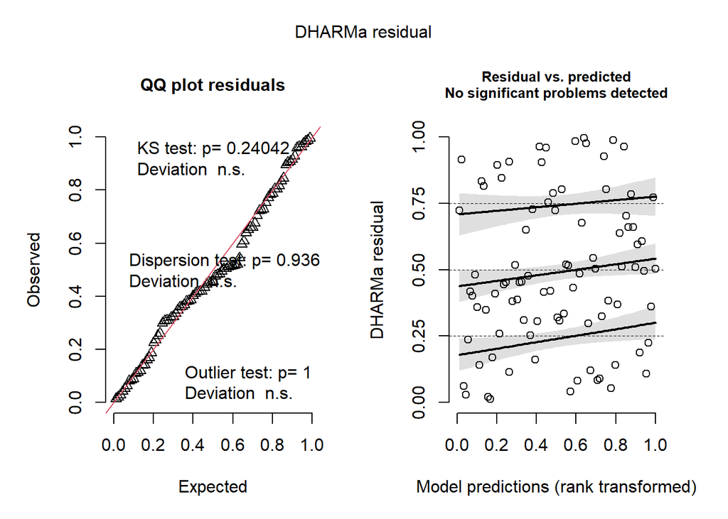

```r
plot(simres <- simulateResiduals(glmm_mudshal3_nb_total))
```